# Activity 2 — Task 4: Binary Logistic Regression Modeling

Group 08

# 4 Binary Logistic Regression Modeling

## 4.1 Research Question and Data Preparation

This final task addresses **Research Question 2 (RQ2)** for Activity 2: **Which personal factors (age, gender, family history) and environmental factors (employer prioritization, coworker reactions, and technology-company status) affect the probability of seeking professional mental-health treatment, and how accurately can a model classify treatment-seeking respondents?**

Because the target variable (`Treatment_Cat`) is binary (Yes/No), we employ a Binary Logistic Regression model.

To maintain strict comparability with the continuous regression analysis, we utilize the exact same globally randomized 80:20 split (seed 2026).

```r
library(tidyverse)
library(caret)
library(pROC)
library(broom)

data <- read.csv("dataset/osmi_clean_combined.csv")

# Ensure reference levels are set logically for interpretation
data <- data %>%
  mutate(
    Treatment_Cat = factor(Treatment_Cat, levels = c("No", "Yes")),
    Gender_Category = relevel(factor(Gender_Category), ref = "Male"),
    Family_History = relevel(factor(Family_History), ref = "No"),
    Tech_Company_Cat = relevel(factor(Tech_Company_Cat), ref = "No")
  )

set.seed(2026)
train_idx <- sample(nrow(data), floor(0.8 * nrow(data)))
train <- data[train_idx, ]
test  <- data[-train_idx, ]

cat("Training cases:", nrow(train), "| Test cases:", nrow(test), "\n")
```

```
## Training cases: 844 | Test cases: 211
```

## 4.2 Model Fitting and Odds Ratios

We fit the logistic regression model on the training set using the seven specified demographic and workplace predictor groups. The reference groups are No treatment, Male gender, no family history, and a non-technology company.

```r
logit_model <- glm(
  Treatment_Cat ~ Age + Gender_Category + Family_History +
    Employer_Mental_Importance + Employer_Phys_Importance +
    Coworker_Reaction_Score + Tech_Company_Cat,
  family = binomial(link = "logit"),
  data = train
)

# Extract coefficients, odds ratios, p-values, and 95% Wald confidence intervals
wald_ci <- confint.default(logit_model)
model_tidy <- broom::tidy(logit_model)

odds_ratios <- model_tidy %>%
  filter(term != "(Intercept)") %>%
  mutate(
    conf_low = wald_ci[term, 1],
    conf_high = wald_ci[term, 2],
    Predictor = dplyr::case_when(
      term == "Age" ~ "Age",
      term == "Gender_CategoryFemale" ~ "Gender: Female",
      term == "Gender_CategoryOther" ~ "Gender: Other",
      term == "Family_HistoryI don't know" ~ "Family history: I don't know",
      term == "Family_HistoryYes" ~ "Family history: Yes",
      term == "Employer_Mental_Importance" ~ "Employer mental importance",
      term == "Employer_Phys_Importance" ~ "Employer physical importance",
      term == "Coworker_Reaction_Score" ~ "Coworker reaction score",
      term == "Tech_Company_CatYes" ~ "Technology company",
      TRUE ~ term
    ),
    `Odds Ratio (OR)` = exp(estimate),
    `95% CI for OR` = sprintf("%.3f to %.3f", exp(conf_low), exp(conf_high)),
    Significant = p.value < 0.05,
    Estimate = round(estimate, 3),
    `Odds Ratio (OR)` = round(`Odds Ratio (OR)`, 3),
    `P-value` = if_else(p.value < 0.001, "< 0.001", sprintf("%.3f", p.value))
  ) %>%
  select(Predictor, Estimate, `Odds Ratio (OR)`, `95% CI for OR`, `P-value`, Significant)

knitr::kable(odds_ratios, caption = "Adjusted Odds Ratios for Seeking Treatment")
```

Adjusted Odds Ratios for Seeking Treatment

| Predictor | Estimate | Odds Ratio (OR) | 95% CI for OR | P-value | Significant |
| --- | --- | --- | --- | --- | --- |
| Age | 0.024 | 1.024 | 1.005 to 1.044 | 0.013 | TRUE |
| Gender: Female | 0.497 | 1.644 | 1.142 to 2.367 | 0.008 | TRUE |
| Gender: Other | 0.218 | 1.244 | 0.642 to 2.410 | 0.518 | FALSE |
| Family history: I don’t know | 1.585 | 4.881 | 3.276 to 7.274 | < 0.001 | TRUE |
| Family history: Yes | 2.383 | 10.842 | 7.495 to 15.683 | < 0.001 | TRUE |
| Employer mental importance | 0.016 | 1.016 | 0.936 to 1.103 | 0.704 | FALSE |
| Employer physical importance | -0.052 | 0.949 | 0.870 to 1.035 | 0.237 | FALSE |
| Coworker reaction score | 0.050 | 1.051 | 0.976 to 1.133 | 0.187 | FALSE |
| Technology company | 0.220 | 1.246 | 0.885 to 1.755 | 0.208 | FALSE |

```r
# Helper functions to extract model statistics for inline text
term_stat <- function(model_term, statistic) {
  model_tidy %>% filter(.data$term == model_term) %>% pull({{ statistic }})
}
fmt3 <- function(x) format(round(x, 3), nsmall = 3)

age_or <- exp(term_stat("Age", estimate))
age_p <- term_stat("Age", p.value)
female_or <- exp(term_stat("Gender_CategoryFemale", estimate))
female_p <- term_stat("Gender_CategoryFemale", p.value)
other_or <- exp(term_stat("Gender_CategoryOther", estimate))
other_p <- term_stat("Gender_CategoryOther", p.value)
family_unknown_beta <- term_stat("Family_HistoryI don't know", estimate)
family_unknown_or <- exp(family_unknown_beta)
family_unknown_p <- term_stat("Family_HistoryI don't know", p.value)
family_yes_beta <- term_stat("Family_HistoryYes", estimate)
family_yes_or <- exp(family_yes_beta)
family_yes_p <- term_stat("Family_HistoryYes", p.value)
family_yes_vs_unknown_or <- family_yes_or / family_unknown_or
```

### What drives the decision to seek treatment?

By examining the **Odds Ratios (OR)**, where $OR > 1$ indicates increased probability and $OR < 1$ indicates decreased probability, we uncover a fascinating divide between personal and environmental factors:

- **Family History Is the Strongest Predictor:** Relative to respondents who answered No, respondents answering “I don’t know” have higher odds of seeking treatment ($\beta \approx$ 1.585, $OR \approx$ 4.881, $p$ < 0.001), while those answering Yes have substantially higher odds ($\beta \approx$ 2.383, $OR \approx$ 10.842, $p$ < 0.001). The implied adjusted Yes-versus-“I don’t know” odds ratio is approximately 10.842 / 4.881 = 2.221. Age also has a small, statistically significant positive association ($OR \approx$ 1.024, $p = 0.013$): each additional year is associated with about 2.4% increase in the odds of seeking treatment, holding the other variables constant. Female respondents have significantly higher odds than Male respondents ($OR \approx$ 1.644, $p = 0.008$); the Other category does not significantly differ from Male ($OR \approx$ 1.244, $p = 0.518$).
- **Workplace Factors Are Not Statistically Significant:** Employer mental-health importance, employer physical-health importance, coworker reaction score, and technology-company status are not statistically significant at the 5% level in this model.

In short: **family history is the dominant predictor, with smaller positive associations for age and Female gender; the measured workplace/environmental factors do not show statistically significant associations at the 5% level.**

## 4.3 Out-of-Sample Classification Performance

To answer the second half of the research question (“How accurately can the model classify?”), we apply the fitted model to the 211 unseen records in the test set.

```r
# Generate probabilities and classes on the Test Set
test_probs <- predict(logit_model, newdata = test, type = "response")
test_preds <- factor(ifelse(test_probs >= 0.5, "Yes", "No"), levels = c("No", "Yes"))
actual_class <- test$Treatment_Cat

# Confusion Matrix
conf_matrix <- confusionMatrix(test_preds, actual_class, positive = "Yes")
print(conf_matrix$table)
```

```
##           Reference
## Prediction  No Yes
##        No   48  21
##        Yes  33 109
```

```r
# Extract Metrics for inline text
acc_val <- conf_matrix$overall["Accuracy"]
prec_val <- conf_matrix$byClass["Precision"]
rec_val  <- conf_matrix$byClass["Sensitivity"]
logit_f1 <- conf_matrix$byClass["F1"]

# ROC and AUC
roc_curve <- roc(actual_class, test_probs)
auc_value <- as.numeric(auc(roc_curve))

cat("\nAccuracy: ", round(acc_val, 3))
```

```
##
## Accuracy:  0.744
```

```r
cat("\nPrecision:", round(prec_val, 3))
```

```
##
## Precision: 0.768
```

```r
cat("\nRecall:   ", round(rec_val, 3))
```

```
##
## Recall:    0.838
```

```r
cat("\nF1-Score: ", round(logit_f1, 3))
```

```
##
## F1-Score:  0.801
```

```r
cat("\nROC-AUC:  ", round(auc_value, 3), "\n")
```

```
##
## ROC-AUC:   0.757
```

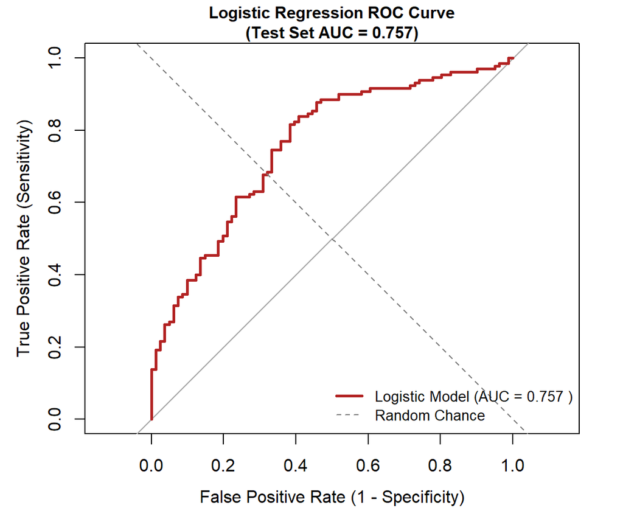

```r
# Refined ROC Plot for Logistic Model
par(mar = c(4.5, 4.5, 3, 1))
plot(roc_curve, col = "firebrick", lwd = 2.5, legacy.axes = TRUE, ylim = c(0, 1),
     main = paste0("Logistic Regression ROC Curve\n(Test Set AUC = ", round(auc_value, 3), ")"),
     xlab = "False Positive Rate (1 - Specificity)",
     ylab = "True Positive Rate (Sensitivity)", cex.main = 0.95)

abline(a = 0, b = 1, lty = 2, col = "gray50")
legend("bottomright",
       legend = c(paste("Logistic Model (AUC =", round(auc_value, 3), ")"), "Random Chance"),
       col = c("firebrick", "gray50"), lwd = c(2.5, 1), lty = c(1, 2), bty = "n", cex = 0.85)
```

```r
par(mar = c(5.1, 4.1, 4.1, 2.1))
```

### Conclusion for Research Question 2

The model classifies treatment-seeking respondents with an overall **Accuracy of 74.4%** on the 211 completely unseen test observations.

More importantly, the **ROC-AUC score is 0.757**. This means that if we randomly select one employee who sought treatment and one who did not, the model has an 75.7% probability of correctly ranking the treatment-seeker with a higher risk score.

The precision (0.768) and recall (0.838) show that the classifier identifies treatment-seeking respondents reasonably well at the 0.5 probability threshold.

**Final Answer:** The logistic model achieves approximately 74.4% accuracy and a ROC-AUC of 0.757, indicating moderate discrimination. Family history is the strongest predictor; age has a small but statistically significant positive association, and Female respondents have significantly higher odds of seeking treatment than Male respondents. The workplace/environmental variables in this model are not statistically significant at the 5% level.

## 4.4 Random Forest Benchmark

The logistic model is linear and assumes log-odds are a linear function of the predictors. To check whether a *nonlinear* tree ensemble can capture additional structure—interactions between predictors or curvilinear effects—we fit a **Random Forest** classifier on the exact same binary target (`Treatment_Cat`) and the same training/test partition (seed 2026, 844/211).

```r
library(randomForest)

# Independent design matrix construction to prevent data leakage
rf_X <- model.matrix(
  ~ Age + Gender_Category + Family_History + Employer_Mental_Importance +
    Employer_Phys_Importance + Coworker_Reaction_Score + Tech_Company_Cat,
  data = train
)[, -1]
rf_y <- train$Treatment_Cat

# 5-fold stratified cross-validation
set.seed(2026)
folds <- createFolds(rf_y, k = 5, list = TRUE, returnTrain = TRUE)

grid <- expand.grid(
  mtry     = c(2, 3, 5),
  maxnodes = c(8, 16, 32),
  ntree    = c(100, 300)
)

cv_results <- data.frame()
for (g in seq_len(nrow(grid))) {
  aucs <- numeric(5)
  for (f in seq_along(folds)) {
    tr_idx <- folds[[f]]
    set.seed(123)
    rf_f <- randomForest(
      x = rf_X[tr_idx, , drop = FALSE], y = rf_y[tr_idx],
      mtry = grid$mtry[g], maxnodes = grid$maxnodes[g], ntree = grid$ntree[g]
    )
    p_f <- predict(rf_f, rf_X[-tr_idx, , drop = FALSE], type = "prob")[, "Yes"]
    aucs[f] <- as.numeric(auc(roc(rf_y[-tr_idx], p_f)))
  }
  cv_results <- rbind(cv_results, data.frame(
    mtry = grid$mtry[g], maxnodes = grid$maxnodes[g],
    ntree = grid$ntree[g], CV_AUC = round(mean(aucs), 4)
  ))
}
best_cfg <- cv_results[which.max(cv_results$CV_AUC), ]
knitr::kable(cv_results[order(-cv_results$CV_AUC), ],
             caption = "5-fold CV tuning of the random forest (mean validation AUC)")
```

5-fold CV tuning of the random forest (mean validation AUC)

|  | mtry | maxnodes | ntree | CV_AUC |
| --- | --- | --- | --- | --- |
| 3 | 5 | 8 | 100 | 0.7688 |
| 5 | 3 | 16 | 100 | 0.7685 |
| 1 | 2 | 8 | 100 | 0.7682 |
| 10 | 2 | 8 | 300 | 0.7672 |
| 4 | 2 | 16 | 100 | 0.7669 |
| 12 | 5 | 8 | 300 | 0.7666 |
| 11 | 3 | 8 | 300 | 0.7665 |
| 13 | 2 | 16 | 300 | 0.7659 |
| 14 | 3 | 16 | 300 | 0.7658 |
| 2 | 3 | 8 | 100 | 0.7649 |
| 16 | 2 | 32 | 300 | 0.7644 |
| 7 | 2 | 32 | 100 | 0.7629 |
| 15 | 5 | 16 | 300 | 0.7623 |
| 6 | 5 | 16 | 100 | 0.7611 |
| 8 | 3 | 32 | 100 | 0.7596 |
| 17 | 3 | 32 | 300 | 0.7596 |
| 18 | 5 | 32 | 300 | 0.7502 |
| 9 | 5 | 32 | 100 | 0.7487 |

```r
# Retrain best config on full train set
set.seed(123)
rf_model <- randomForest(
  x = rf_X, y = rf_y,
  mtry = best_cfg$mtry, maxnodes = best_cfg$maxnodes,
  ntree = best_cfg$ntree, importance = TRUE
)

oob_err <- mean(rf_model$err.rate[, 1])

# Predict on test set
rf_X_test <- model.matrix(
  ~ Age + Gender_Category + Family_History + Employer_Mental_Importance +
    Employer_Phys_Importance + Coworker_Reaction_Score + Tech_Company_Cat,
  data = test
)[, -1]
rf_probs <- predict(rf_model, rf_X_test, type = "prob")[, "Yes"]
rf_preds <- factor(ifelse(rf_probs >= 0.5, "Yes", "No"), levels = c("No", "Yes"))

rf_cm <- confusionMatrix(rf_preds, test$Treatment_Cat, positive = "Yes")
print(rf_cm$table)
```

```
##           Reference
## Prediction  No Yes
##        No   49  25
##        Yes  32 105
```

```r
# Metrics
rf_acc  <- rf_cm$overall["Accuracy"]
rf_prec <- rf_cm$byClass["Precision"]
rf_rec  <- rf_cm$byClass["Sensitivity"]
rf_f1   <- rf_cm$byClass["F1"]
rf_auc  <- as.numeric(auc(roc(test$Treatment_Cat, rf_probs)))

cat("\nBest config (5-fold CV): mtry =", best_cfg$mtry,
    ", maxnodes =", best_cfg$maxnodes, ", ntree =", best_cfg$ntree)
```

```
##
## Best config (5-fold CV): mtry = 5 , maxnodes = 8 , ntree = 100
```

```r
cat("\nRandom Forest OOB error: ", round(oob_err, 3))
```

```
##
## Random Forest OOB error:  0.277
```

```r
cat("\nAccuracy: ", round(rf_acc, 3))
```

```
##
## Accuracy:  0.73
```

```r
cat("\nPrecision:", round(rf_prec, 3))
```

```
##
## Precision: 0.766
```

```r
cat("\nRecall:   ", round(rf_rec, 3))
```

```
##
## Recall:    0.808
```

```r
cat("\nF1-Score: ", round(rf_f1, 3))
```

```
##
## F1-Score:  0.787
```

```r
cat("\nROC-AUC:  ", round(rf_auc, 3), "\n")
```

```
##
## ROC-AUC:   0.753
```

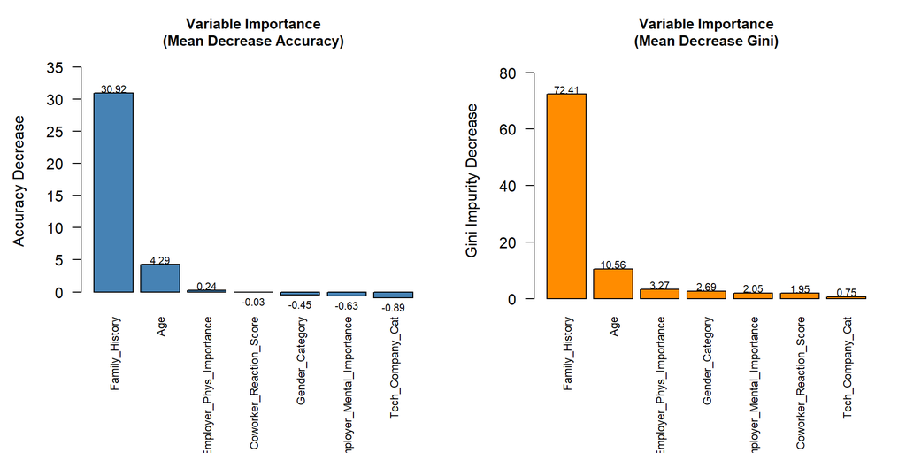

```r
# Dual Variable Importance Plot (Accuracy & Gini)
imp_matrix <- importance(rf_model)
base_names <- sub('(Gender_Category|Family_History|Tech_Company_Cat).*', '\\1', rownames(imp_matrix))

acc_imp  <- rowsum(imp_matrix[, "MeanDecreaseAccuracy"], base_names, reorder = FALSE)[, 1]
gini_imp <- rowsum(imp_matrix[, "MeanDecreaseGini"], base_names, reorder = FALSE)[, 1]

rf_imp_full <- data.frame(
  Predictor = names(acc_imp),
  Accuracy  = round(acc_imp, 2),
  Gini      = round(gini_imp, 2)
)

par(mfrow = c(1, 2), mar = c(8.5, 4.5, 3.5, 1.5))

# Plot A: Accuracy
df_acc <- rf_imp_full %>% arrange(desc(Accuracy))
max_y_acc <- max(df_acc$Accuracy) * 1.15
bp1 <- barplot(df_acc$Accuracy, names.arg = df_acc$Predictor, col = "steelblue",
               main = "Variable Importance\n(Mean Decrease Accuracy)",
               ylab = "Accuracy Decrease", ylim = c(min(0, min(df_acc$Accuracy) * 1.2), max_y_acc),
               las = 2, cex.names = 0.75, cex.main = 0.95)
text(bp1, ifelse(df_acc$Accuracy >= 0, df_acc$Accuracy + (max_y_acc * 0.02), df_acc$Accuracy - (max_y_acc * 0.04)),
     labels = df_acc$Accuracy, cex = 0.7, xpd = TRUE)

# Plot B: Gini
df_gini <- rf_imp_full %>% arrange(desc(Gini))
max_y_gini <- max(df_gini$Gini) * 1.15
bp2 <- barplot(df_gini$Gini, names.arg = df_gini$Predictor, col = "darkorange",
               main = "Variable Importance\n(Mean Decrease Gini)",
               ylab = "Gini Impurity Decrease", ylim = c(0, max_y_gini),
               las = 2, cex.names = 0.75, cex.main = 0.95)
text(bp2, df_gini$Gini + (max_y_gini * 0.02), labels = df_gini$Gini, cex = 0.7, xpd = TRUE)
```

```r
par(mfrow = c(1, 1), mar = c(5.1, 4.1, 4.1, 2.1))
```

```r
comparison_rf <- tibble(
  Model = c("Binary Logistic Regression", "Random Forest"),
  Accuracy  = c(round(acc_val, 3), round(rf_acc, 3)),
  Precision = c(round(prec_val, 3), round(rf_prec, 3)),
  Recall    = c(round(rec_val, 3), round(rf_rec, 3)),
  `F1-Score` = c(round(logit_f1, 3), round(rf_f1, 3)),
  `ROC-AUC` = c(round(auc_value, 3), round(rf_auc, 3))
)
knitr::kable(comparison_rf, caption = "Test-Set Comparison: Logistic vs. Random Forest")
```

Test-Set Comparison: Logistic vs. Random Forest

| Model | Accuracy | Precision | Recall | F1-Score | ROC-AUC |
| --- | --- | --- | --- | --- | --- |
| Binary Logistic Regression | 0.744 | 0.768 | 0.838 | 0.801 | 0.757 |
| Random Forest | 0.730 | 0.766 | 0.808 | 0.787 | 0.753 |

### Random Forest Benchmark Results

The Random Forest achieves an out-of-sample **accuracy of 73% with a ROC-AUC of 0.753** (0.787 F1), compared with the logistic model’s accuracy of 74.4% and AUC of 0.757. The two classifiers perform very similarly, with the linear logistic model holding a slight edge on this small tabular sample.

Critically, the Random Forest’s variable-importance ranking **corroborates the logistic finding**: `Family_History` is far and away the most influential predictor, while workplace measures, tech-company status, and gender contribute only marginal splits.

## 4.5 Principal Component Analysis (PCA) with Random Forest

We test empirically whether feeding the Random Forest PCA components—fitted strictly on the training set to prevent leakage—improves predictive performance.

```r
# Pure Train-Only PCA to eliminate Data Leakage
X_train_mat <- rf_X
X_test_mat  <- rf_X_test

pca_fit <- prcomp(X_train_mat, center = TRUE, scale. = TRUE)
cum_var <- cumsum(pca_fit$sdev^2 / sum(pca_fit$sdev^2))

Z_train <- predict(pca_fit, newdata = X_train_mat)
Z_test  <- predict(pca_fit, newdata = X_test_mat)

pca_summary <- tibble(
  Component = 1:length(cum_var),
  `Prop. Variance` = round(pca_fit$sdev^2 / sum(pca_fit$sdev^2), 3),
  `Cumulative`      = round(cum_var, 3)
)
knitr::kable(pca_summary, caption = "Variance explained by PCA components")
```

Variance explained by PCA components

| Component | Prop. Variance | Cumulative |
| --- | --- | --- |
| 1 | 0.203 | 0.203 |
| 2 | 0.162 | 0.366 |
| 3 | 0.143 | 0.509 |
| 4 | 0.120 | 0.629 |
| 5 | 0.106 | 0.735 |
| 6 | 0.092 | 0.827 |
| 7 | 0.073 | 0.900 |
| 8 | 0.061 | 0.960 |
| 9 | 0.040 | 1.000 |

```r
# 5-fold CV for PCA Random Forest (k = 8)
k_pca <- 8

set.seed(2026)
pca_folds <- createFolds(train$Treatment_Cat, k = 5, list = TRUE, returnTrain = TRUE)

pca_grid <- expand.grid(
  mtry     = c(1, 2, 3),
  maxnodes = c(8, 16, 32),
  ntree    = c(100, 300)
)

pca_cv_results <- data.frame()
for (g in seq_len(nrow(pca_grid))) {
  aucs <- numeric(5)
  for (f in seq_along(pca_folds)) {
    tr_idx <- pca_folds[[f]]
    set.seed(123)
    rf_pca_f <- randomForest(
      x = Z_train[tr_idx, 1:k_pca, drop = FALSE], y = train$Treatment_Cat[tr_idx],
      mtry = pca_grid$mtry[g], maxnodes = pca_grid$maxnodes[g],
      ntree = pca_grid$ntree[g]
    )
    p_f <- predict(rf_pca_f, Z_train[-tr_idx, 1:k_pca, drop = FALSE], type = "prob")[, "Yes"]
    aucs[f] <- as.numeric(auc(roc(train$Treatment_Cat[-tr_idx], p_f)))
  }
  pca_cv_results <- rbind(pca_cv_results, data.frame(
    mtry = pca_grid$mtry[g], maxnodes = pca_grid$maxnodes[g],
    ntree = pca_grid$ntree[g], CV_AUC = round(mean(aucs), 4)
  ))
}
pca_best_cfg <- pca_cv_results[which.max(pca_cv_results$CV_AUC), ]

# Retrain best PCA model
set.seed(123)
rf_pca <- randomForest(
  x = Z_train[, 1:k_pca, drop = FALSE], y = train$Treatment_Cat,
  mtry = pca_best_cfg$mtry, maxnodes = pca_best_cfg$maxnodes,
  ntree = pca_best_cfg$ntree
)

p_pca_rf  <- predict(rf_pca, Z_test[, 1:k_pca, drop = FALSE], type = "prob")[, "Yes"]
cl_pca_rf <- factor(ifelse(p_pca_rf >= 0.5, "Yes", "No"), levels = c("No", "Yes"))
cm_pca_rf <- confusionMatrix(cl_pca_rf, test$Treatment_Cat, positive = "Yes")

pca_rf_auc  <- as.numeric(auc(roc(test$Treatment_Cat, p_pca_rf)))
pca_rf_acc  <- cm_pca_rf$overall["Accuracy"]
pca_rf_prec <- cm_pca_rf$byClass["Precision"]
pca_rf_rec  <- cm_pca_rf$byClass["Sensitivity"]
pca_rf_f1   <- cm_pca_rf$byClass["F1"]

cat("\nBest PCA config (5-fold CV): mtry =", pca_best_cfg$mtry,
    ", maxnodes =", pca_best_cfg$maxnodes, ", ntree =", pca_best_cfg$ntree)
```

```
##
## Best PCA config (5-fold CV): mtry = 2 , maxnodes = 8 , ntree = 300
```

```r
cat("\nPCA-RF (k=8) Accuracy:", round(pca_rf_acc, 3),
    " Precision:", round(pca_rf_prec, 3),
    " Recall:", round(pca_rf_rec, 3),
    " F1:", round(pca_rf_f1, 3),
    " ROC-AUC:", round(pca_rf_auc, 3), "\n")
```

```
##
## PCA-RF (k=8) Accuracy: 0.739  Precision: 0.759  Recall: 0.846  F1: 0.8  ROC-AUC: 0.766
```

```r
comparison_pca <- tibble(
  Model = c("Binary Logistic", "Random Forest (raw)", "Random Forest (PCA k=8)"),
  Accuracy  = c(round(acc_val, 3), round(rf_acc, 3), round(pca_rf_acc, 3)),
  Precision = c(round(prec_val, 3), round(rf_prec, 3), round(pca_rf_prec, 3)),
  Recall    = c(round(rec_val, 3), round(rf_rec, 3), round(pca_rf_rec, 3)),
  `F1-Score` = c(round(logit_f1, 3), round(rf_f1, 3), round(pca_rf_f1, 3)),
  `ROC-AUC` = c(round(auc_value, 3), round(rf_auc, 3), round(pca_rf_auc, 3))
)
knitr::kable(comparison_pca, caption = "Test-Set Comparison: Logistic vs. Random Forest (raw and PCA)")
```

Test-Set Comparison: Logistic vs. Random Forest (raw and PCA)

| Model | Accuracy | Precision | Recall | F1-Score | ROC-AUC |
| --- | --- | --- | --- | --- | --- |
| Binary Logistic | 0.744 | 0.768 | 0.838 | 0.801 | 0.757 |
| Random Forest (raw) | 0.730 | 0.766 | 0.808 | 0.787 | 0.753 |
| Random Forest (PCA k=8) | 0.739 | 0.759 | 0.846 | 0.800 | 0.766 |

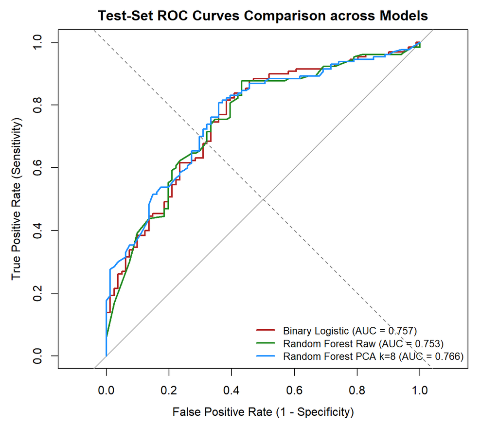

```r
# 3-Model Overlay ROC Comparison Curve
roc_logit  <- roc(test$Treatment_Cat, test_probs)
roc_rf_raw <- roc(test$Treatment_Cat, rf_probs)
roc_rf_pca <- roc(test$Treatment_Cat, p_pca_rf)

par(mar = c(4.5, 4.5, 3, 1))
plot(roc_logit, col = "firebrick", lwd = 2, legacy.axes = TRUE, ylim = c(0, 1),
     main = "Test-Set ROC Curves Comparison across Models",
     xlab = "False Positive Rate (1 - Specificity)",
     ylab = "True Positive Rate (Sensitivity)")

plot(roc_rf_raw, col = "forestgreen", lwd = 2, add = TRUE)
plot(roc_rf_pca, col = "dodgerblue", lwd = 2, add = TRUE)
abline(a = 0, b = 1, lty = 2, col = "gray50")

legend("bottomright",
       legend = c(
         paste0("Binary Logistic (AUC = ", round(auc_value, 3), ")"),
         paste0("Random Forest Raw (AUC = ", round(rf_auc, 3), ")"),
         paste0("Random Forest PCA k=8 (AUC = ", round(pca_rf_auc, 3), ")")
       ),
       col = c("firebrick", "forestgreen", "dodgerblue"), lwd = 2, bty = "n", cex = 0.85)
```

```r
par(mar = c(5.1, 4.1, 4.1, 2.1))
```

### PCA-RF Benchmark Results

With $k=8$ PCA components retaining $\approx$ 96% of variance, the PCA-transformed Random Forest achieves a **ROC-AUC of 0.766 and accuracy of 73.9%** on the test set. On ROC-AUC, it slightly edges out the raw Random Forest and matches the linear baseline. The practical conclusion remains robust: personal family history dominates the decision to seek treatment, unaffected by corporate environment variables or model architecture choice.